# Renal Data Survival Analysis

Chenhuan Li

## Dataset

```r
library(tidyverse)
library(SurvRegCensCov)
library(survival)
library(km.ci)
library(tableone)
```

```r
renal <- read.table("renal_data.txt", header = TRUE)

# data type manage
renal$medgroup <- factor(renal$medgroup, levels = c(0, 1), labels = c("Treatment A", "Treatment B"))
renal$sex <- factor(renal$sex, levels = c(0, 1), labels = c("Female", "Male"))
renal$heartfailure <- factor(renal$heartfailure, levels = c(0, 1), labels = c("No", "Yes"))
renal$livercirrhosis <- factor(renal$livercirrhosis, levels = c(0, 1), labels = c("No", "Yes"))
renal$eGFRstage <- factor(renal$eGFRstage) # eGFR 1-5 ，factor

## descriptive statistics
myVars <- c("age", "sex", "BMI", "heartfailure", "livercirrhosis", "eGFRstage", "status_DT")

catVars <- c("sex", "heartfailure", "livercirrhosis", "eGFRstage", "status_DT")

tab1 <- CreateTableOne(vars = myVars,
                       strata = "medgroup",
                       data = renal,
                       factorVars = catVars)

print(tab1, showAllLevels = TRUE, nonnormal = c("BMI", "age"), test = FALSE)
```

```
##                     Stratified by medgroup
##                      level  Treatment A          Treatment B
##   n                          1500                  650
##   age (median [IQR])        58.00 [47.00, 69.00] 62.00 [49.00, 73.00]
##   sex (%)            Female   327 (21.8)           149 (22.9)
##                      Male    1173 (78.2)           501 (77.1)
##   BMI (median [IQR])        24.90 [22.70, 26.80] 24.70 [22.72, 26.90]
##   heartfailure (%)   No      1492 (99.5)           627 (96.5)
##                      Yes        8 ( 0.5)            23 ( 3.5)
##   livercirrhosis (%) No      1467 (97.8)           636 (97.8)
##                      Yes       33 ( 2.2)            14 ( 2.2)
##   eGFRstage (%)      1        293 (19.5)            41 ( 6.3)
##                      2        471 (31.4)           103 (15.8)
##                      3        272 (18.1)            96 (14.8)
##                      4        257 (17.1)           204 (31.4)
##                      5        207 (13.8)           206 (31.7)
##   status_DT (%)      0       1386 (92.4)           547 (84.2)
##                      1        114 ( 7.6)           103 (15.8)
```

## Kaplan-Meier Curve

```r
# 在不考虑患者其他身体条件差异的情况下，直观比较两组药物的效果。

library(survival)
library(survminer)
```

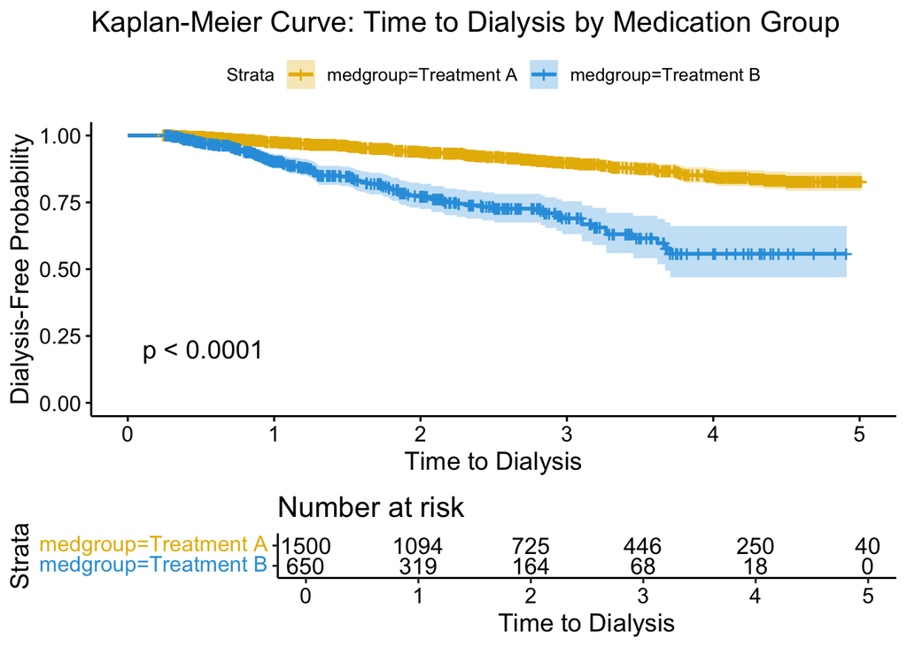

```r
km_fit <- survfit(Surv(time_DT, status_DT) ~ medgroup, data = renal)

KM_plot <- ggsurvplot(km_fit,
           data = renal,
           pval = TRUE,
           conf.int = TRUE,
           risk.table = TRUE,
           title = "Kaplan-Meier Curve: Time to Dialysis by Medication Group",
           xlab = "Time to Dialysis",
           ylab = "Dialysis-Free Probability",
           palette = c("#E7B800", "#2E9FDF"))

print(KM_plot)
```

From Kaplan-Meier plot, we can observe a highly *significant difference* between the two treatment groups, with a log-rank p-value of less than 0.0001.” KM 曲线:我们可以观察到两组治疗具有极其显著的差异，Log-rank 检验的 $p$ 值小于 0.0001

Patients in Treatment A (the yellow line) show a significantly higher dialysis-free probability compared to Treatment B (the blue line). Treatment A 组（黄色线）的无透析概率显著高于 Treatment B 组

The risk table shows that we have a *sufficient sample size* in both groups at the start, though the number at risk drops over time due to events and censoring. 风险表:我们在开始时两组都有充足的样本量，尽管随着事件发生和删失，风险人数随时间下降。

## Cox’s Proportional Hazards Model

```r
# holding other covariates constant
cox_model <- coxph(Surv(time_DT, status_DT) ~ medgroup + age + sex + BMI +
                   heartfailure + livercirrhosis + eGFRstage,
                 data = renal)

summary(cox_model)
```

```
## Call:
## coxph(formula = Surv(time_DT, status_DT) ~ medgroup + age + sex +
##     BMI + heartfailure + livercirrhosis + eGFRstage, data = renal)
##
##   n= 2150, number of events= 217
##
##                          coef exp(coef)  se(coef)      z Pr(>|z|)
## medgroupTreatment B  0.852220  2.344847  0.145693  5.849 4.93e-09 ***
## age                 -0.013233  0.986854  0.004422 -2.993  0.00277 **
## sexMale             -0.302157  0.739222  0.146756 -2.059  0.03950 *
## BMI                 -0.014927  0.985184  0.010009 -1.491  0.13589
## heartfailureYes      1.000144  2.718673  0.389250  2.569  0.01019 *
## livercirrhosisYes    0.920520  2.510594  0.342956  2.684  0.00727 **
## eGFRstage2          -1.200585  0.301018  0.478592 -2.509  0.01212 *
## eGFRstage3          -0.647578  0.523312  0.464083 -1.395  0.16290
## eGFRstage4           0.548035  1.729851  0.346159  1.583  0.11338
## eGFRstage5           2.158047  8.654221  0.319707  6.750 1.48e-11 ***
## ---
## Signif. codes:  0 '***' 0.001 '**' 0.01 '*' 0.05 '.' 0.1 ' ' 1
##
##                     exp(coef) exp(-coef) lower .95 upper .95
## medgroupTreatment B    2.3448     0.4265    1.7624    3.1198
## age                    0.9869     1.0133    0.9783    0.9954
## sexMale                0.7392     1.3528    0.5544    0.9856
## BMI                    0.9852     1.0150    0.9660    1.0047
## heartfailureYes        2.7187     0.3678    1.2677    5.8303
## livercirrhosisYes      2.5106     0.3983    1.2819    4.9170
## eGFRstage2             0.3010     3.3221    0.1178    0.7691
## eGFRstage3             0.5233     1.9109    0.2107    1.2995
## eGFRstage4             1.7299     0.5781    0.8777    3.4093
## eGFRstage5             8.6542     0.1156    4.6248   16.1943
##
## Concordance= 0.831  (se = 0.016 )
## Likelihood ratio test= 392.5  on 10 df,   p=<2e-16
## Wald test            = 307.9  on 10 df,   p=<2e-16
## Score (logrank) test = 527.9  on 10 df,   p=<2e-16
```

To further validate our findings and adjust for potential confounders. 验证,校正潜在的混杂因素

The results are highly *robust*. Even after *controlling for age, BMI, comorbidities, and eGFR stages*, patients on Treatment B have a *2.34 times higher hazard* of the event (dialysis) compared to Treatment A, with a p-value of less than 0.0001 即使在控制了其他变量后，与治疗 A 相比，治疗 B 透析的风险增加了 2.34 倍

## Variable selection

```r
# stepwise model selection base on AIC
optimal_model <- step(cox_model, direction = "both")
```

```
## Start:  AIC=2628.86
## Surv(time_DT, status_DT) ~ medgroup + age + sex + BMI + heartfailure +
##     livercirrhosis + eGFRstage
##
##                  Df    AIC
## <none>              2628.9
## - BMI             1 2630.3
## - sex             1 2631.0
## - heartfailure    1 2631.8
## - livercirrhosis  1 2632.4
## - age             1 2635.5
## - medgroup        1 2660.3
## - eGFRstage       4 2861.3
```

```r
# Optimal Model
summary(optimal_model)
```

```
## Call:
## coxph(formula = Surv(time_DT, status_DT) ~ medgroup + age + sex +
##     BMI + heartfailure + livercirrhosis + eGFRstage, data = renal)
##
##   n= 2150, number of events= 217
##
##                          coef exp(coef)  se(coef)      z Pr(>|z|)
## medgroupTreatment B  0.852220  2.344847  0.145693  5.849 4.93e-09 ***
## age                 -0.013233  0.986854  0.004422 -2.993  0.00277 **
## sexMale             -0.302157  0.739222  0.146756 -2.059  0.03950 *
## BMI                 -0.014927  0.985184  0.010009 -1.491  0.13589
## heartfailureYes      1.000144  2.718673  0.389250  2.569  0.01019 *
## livercirrhosisYes    0.920520  2.510594  0.342956  2.684  0.00727 **
## eGFRstage2          -1.200585  0.301018  0.478592 -2.509  0.01212 *
## eGFRstage3          -0.647578  0.523312  0.464083 -1.395  0.16290
## eGFRstage4           0.548035  1.729851  0.346159  1.583  0.11338
## eGFRstage5           2.158047  8.654221  0.319707  6.750 1.48e-11 ***
## ---
## Signif. codes:  0 '***' 0.001 '**' 0.01 '*' 0.05 '.' 0.1 ' ' 1
##
##                     exp(coef) exp(-coef) lower .95 upper .95
## medgroupTreatment B    2.3448     0.4265    1.7624    3.1198
## age                    0.9869     1.0133    0.9783    0.9954
## sexMale                0.7392     1.3528    0.5544    0.9856
## BMI                    0.9852     1.0150    0.9660    1.0047
## heartfailureYes        2.7187     0.3678    1.2677    5.8303
## livercirrhosisYes      2.5106     0.3983    1.2819    4.9170
## eGFRstage2             0.3010     3.3221    0.1178    0.7691
## eGFRstage3             0.5233     1.9109    0.2107    1.2995
## eGFRstage4             1.7299     0.5781    0.8777    3.4093
## eGFRstage5             8.6542     0.1156    4.6248   16.1943
##
## Concordance= 0.831  (se = 0.016 )
## Likelihood ratio test= 392.5  on 10 df,   p=<2e-16
## Wald test            = 307.9  on 10 df,   p=<2e-16
## Score (logrank) test = 527.9  on 10 df,   p=<2e-16
```

Optimal Model=Full Model AIC cares about the overall predictive performance, AIC balances the goodness-of-fit with a penalty for model complexity

## Cox-Snell Residual Plot

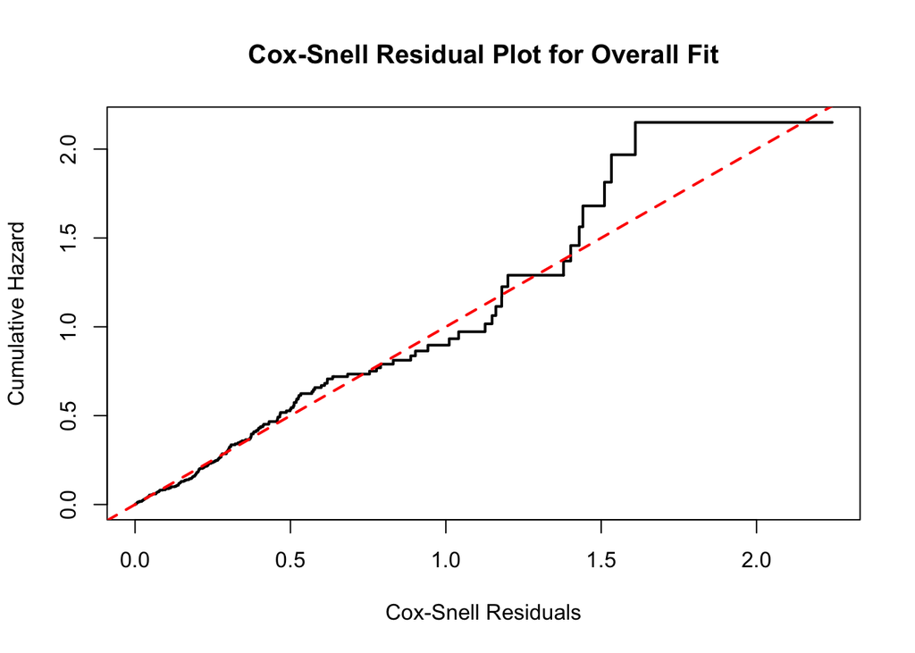

```r
library(survival)

# Martingale Residual
res_mart <- residuals(optimal_model, type = "martingale")

# Cox-Snell Residual
cs_residuals <- renal$status_DT - res_mart

fit_cs <- survfit(Surv(cs_residuals, renal$status_DT) ~ 1)

# plot X:Cox-Snell Residuals，y:Cumulative Hazard)
plot(fit_cs$time, -log(fit_cs$surv), type = "s",
     xlab = "Cox-Snell Residuals",
     ylab = "Cumulative Hazard",
     main = "Cox-Snell Residual Plot for Overall Fit",
     lwd = 2)

# 45-degree reference line
abline(0, 1, col = "red", lty = 2, lwd = 2)
```

To confirm the overall goodness-of-fit, I derived the Cox-Snell residuals. As shown in this plot, the estimated cumulative hazard function *closely follows* the 45-degree reference line, especially in the main body of the data(early and middle). This indicates that the chosen model structure and baseline hazard fit the actual data well.

## Hypothesis Testing

```r
# PH Assumption - Schoenfeld Residuals
ph_optimal <- cox.zph(optimal_model)
print(ph_optimal)
```

```
##                  chisq df     p
## medgroup        0.0216  1 0.883
## age             0.0515  1 0.821
## sex             5.7893  1 0.016
## BMI             0.8033  1 0.370
## heartfailure    0.0739  1 0.786
## livercirrhosis  0.7483  1 0.387
## eGFRstage       9.7972  4 0.044
## GLOBAL         14.6410 10 0.146
```

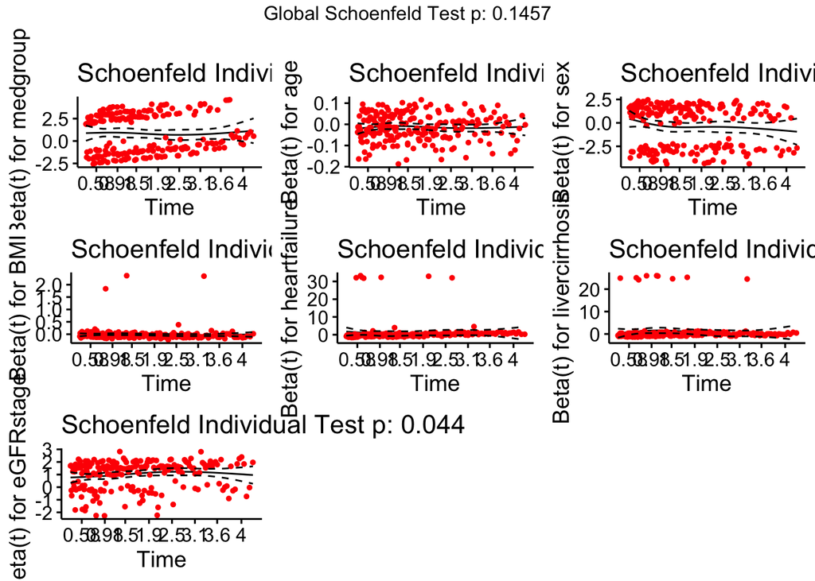

```r
# plot
Schoenfeld_plot <- ggcoxzph(ph_optimal)
print(Schoenfeld_plot)
```

the Hazard Ratio for each predictor remains constant *over time*. Mathematically, it tests the correlation between the Schoenfeld residuals and survival time.

Model diagnostics.模型诊断 GLOBAL P=0.146, the Proportional Hazards assumption holds.模型整体可靠

sex p= 1 0.016

eGFRstage p= 4 0.044

This means that the effects of sex and eGFR stage on dialysis are not *constant*. plot: smoothed curve only *deviates slightly* from zero at the extreme tails, might be acceptable

if not acceptable, use Stratified Cox Model

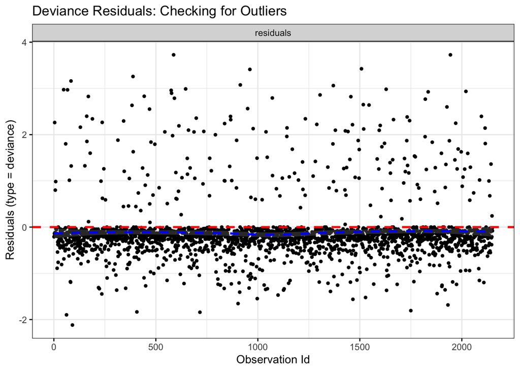

```r
#Deviance Residuals)
# 目的：检查数据里有没有“极品病人”（比如病情极其严重却活了极久，把整个模型带偏了）
#
Deviance_plot <- ggcoxdiagnostics(optimal_model,
                                  type = "deviance",
                                  linear.predictions = FALSE,
                                  ggtheme = theme_bw(),
                                  title = "Deviance Residuals: Checking for Outliers")
print(Deviance_plot)
```

the data points are distributed around zero, largely bounded within the normal range, indicating an nice goodness-of-fit without severe influential outliers.

## Stratified Cox Model

```r
# 假设对 sex 和 eGFRstage 进行分层
stratified_model <- coxph(Surv(time_DT, status_DT) ~ medgroup + age + BMI +
                          heartfailure + livercirrhosis +
                          strata(sex) + strata(eGFRstage), data = renal)
summary(stratified_model)
```

```
## Call:
## coxph(formula = Surv(time_DT, status_DT) ~ medgroup + age + BMI +
##     heartfailure + livercirrhosis + strata(sex) + strata(eGFRstage),
##     data = renal)
##
##   n= 2150, number of events= 217
##
##                          coef exp(coef)  se(coef)      z Pr(>|z|)
## medgroupTreatment B  0.864907  2.374786  0.147447  5.866 4.47e-09 ***
## age                 -0.013213  0.986874  0.004447 -2.971  0.00297 **
## BMI                 -0.013996  0.986101  0.009680 -1.446  0.14821
## heartfailureYes      1.069581  2.914159  0.390131  2.742  0.00611 **
## livercirrhosisYes    0.964688  2.623970  0.345390  2.793  0.00522 **
## ---
## Signif. codes:  0 '***' 0.001 '**' 0.01 '*' 0.05 '.' 0.1 ' ' 1
##
##                     exp(coef) exp(-coef) lower .95 upper .95
## medgroupTreatment B    2.3748     0.4211    1.7788    3.1705
## age                    0.9869     1.0133    0.9783    0.9955
## BMI                    0.9861     1.0141    0.9676    1.0050
## heartfailureYes        2.9142     0.3432    1.3565    6.2603
## livercirrhosisYes      2.6240     0.3811    1.3334    5.1636
##
## Concordance= 0.646  (se = 0.024 )
## Likelihood ratio test= 58.65  on 5 df,   p=2e-11
## Wald test            = 60.15  on 5 df,   p=1e-11
## Score (logrank) test = 64.09  on 5 df,   p=2e-12
```

The HR for medgroup Treatment B is now 2.37 (previously 2.34), shifted slightly, and the P-value remains *significant* at 4.47e-09. This conclusion *still reliable* after removing the influence of pH violation.

## Accelerated Failure Time (AFT) model

```r
library(survival)
#  WeibullAFT
aft_model <- survreg(Surv(time_DT, status_DT) ~ medgroup + age + BMI + heartfailure + livercirrhosis + sex + eGFRstage, data = renal, dist = "weibull")
summary(aft_model)
```

```
##
## Call:
## survreg(formula = Surv(time_DT, status_DT) ~ medgroup + age +
##     BMI + heartfailure + livercirrhosis + sex + eGFRstage, data = renal,
##     dist = "weibull")
##                        Value Std. Error     z       p
## (Intercept)          2.05034    0.29405  6.97 3.1e-12
## medgroupTreatment B -0.55466    0.08799 -6.30 2.9e-10
## age                  0.00833    0.00278  2.99  0.0028
## BMI                  0.00994    0.00639  1.56  0.1195
## heartfailureYes     -0.63924    0.24130 -2.65  0.0081
## livercirrhosisYes   -0.59176    0.21423 -2.76  0.0057
## sexMale              0.19287    0.09143  2.11  0.0349
## eGFRstage2           0.75795    0.29967  2.53  0.0114
## eGFRstage3           0.41066    0.28914  1.42  0.1555
## eGFRstage4          -0.32736    0.21679 -1.51  0.1310
## eGFRstage5          -1.34751    0.21234 -6.35 2.2e-10
## Log(scale)          -0.47464    0.05300 -8.96 < 2e-16
##
## Scale= 0.622
##
## Weibull distribution
## Loglik(model)= -644.1   Loglik(intercept only)= -847.4
##  Chisq= 406.55 on 10 degrees of freedom, p= 3.8e-81
## Number of Newton-Raphson Iterations: 12
## n= 2150
```

Treatment B has a highly *significant* negative coefficient (-0.55), meaning it significantly accelerates the time to dialysis. Being on Treatment B ‘accelerates’ the disease progression, shrinking the dialysis-free time by about $1-\exp(-0.55466) \approx 0.43$ = 43% compared to Treatment A.

```r
beta_aft <- coef(aft_model)
scale_val <- aft_model$scale

# dividing the negative AFT coefficients by the scale parameter(log Hazard Ratios)
beta_ph <- -beta_aft / scale_val

# convert the results to Hazard Ratios (HR)
HR_converted <- exp(beta_ph)

aft_to_hr_table <- data.frame(
  AFT_Coefficient = beta_aft,
  Converted_Cox_Coef = beta_ph,
  Converted_HR = HR_converted
)
print(round(aft_to_hr_table[-1, ], 3))
```

```
##                     AFT_Coefficient Converted_Cox_Coef Converted_HR
## medgroupTreatment B          -0.555              0.892        2.439
## age                           0.008             -0.013        0.987
## BMI                           0.010             -0.016        0.984
## heartfailureYes              -0.639              1.028        2.794
## livercirrhosisYes            -0.592              0.951        2.589
## sexMale                       0.193             -0.310        0.733
## eGFRstage2                    0.758             -1.218        0.296
## eGFRstage3                    0.411             -0.660        0.517
## eGFRstage4                   -0.327              0.526        1.693
## eGFRstage5                   -1.348              2.166        8.724
```

The converted HR for Treatment B is 2.439, which confirms Cox findings (HR=2.34，2.37),